# Math 120 Week 07

Prof Miller

09 March, 2020

# Tuesday

## Using the z table in practical real-world scenarios

In the real world, there are lots of different normal dists. SPecifically, different centers and spread! Example: human height.

To use the z table (std normal, mean=0, stdev = 1) in these scenarios, we need to do a little extra work.

## Forwards

Remember: forwards means we start with a value, need to find a probability/area.

For real-world data, we need to find z scores on our own! Exactly the same as before.

Formula:

z = (x-mu)/sigma = (x-xbar)/s

So, first get z, then use table. Bam!

Example) Height for adult men (20-29) in the US follows a normal dist with mean = 69" and std dev = 2.7".

What’s the prob that a randomly selected man is less than 6’ tall? (72")

First: z score. x = 72. mu = 69, sigma = 2.7

```r
(72-69)/2.7
```

```
## [1] 1.111111
```

So, P(X<72) = P(Z < 1.11) = .8665

There’s about an 86.65% chance that a rando man is less than 6’ tall.

Example) Height for adult women follows a normal dist with mean = 64" and std dev = 2.4“. What’s the probility that a rando woman is between 5’6” (66“) and 5’8” (68").

z-scores:

```r
(68-64)/2.4
```

```
## [1] 1.666667
```

```r
(66-64)/2.4
```

```
## [1] 0.8333333
```

P( 0.83 < Z < 1.67) = P(Z<1.67) - P(Z < 0.83)

```r
.9525-.7967
```

```
## [1] 0.1558
```

There’s a 15.58% chance that rando woman is between 5’6" and 5’8".

## Backwards

Remember: backwards means we start with prob/area, find cutoff/value/measurement/obs.

Example) How tall must a woman be in order to be in the top 5% of womens’ heights?

First: look for area in table, find z-score.

Note: if two z-scores are equally good, just spilt them. Ie. average.

Here: z=1.64 and z=1.65 are equally close, use z=1.645.

Got z, what’s x?

```r
1.645*2.4+64
```

```
## [1] 67.948
```

She’d have to be 5’7.948“. I.e., 67.948”.

Note, since z = (x-mu)/sigma,

x = z*sigma+mu

Example) How tall must a rando man be in order to be in the top 15% of mens’ heights? Recall, mean = 69, sigma = 2.7.

```r
1.04*2.7+69
```

```
## [1] 71.808
```

He’d have to be 71.8" tall in order to be in the top 15%.

## Sampling distro

Suppose I roll a dice a bunch of times, and make a histogram of the resulsts.

What shape would the histo have? Expect a flat line.

Dice rolling activity

Take turns rolling the dice. Every student rolls 50 times. While one student rolls, the other records.

# Tuesday

## Z table for real-world scenarios

There are lots of normal dists out there (different centers and spreads), but the z table only shows STANDARD normal (mean=0, stdev=1).

To use z table, we first need to convert to standard normal.

This is easy: z-scores!

## Forwards problems

Recall, forwards: start with a value/observation, find prob/area.

For real-world data, same thing, just find z-scores first!

Example) Height for men in the US (20-29) follows a normal dist with mean = 69" and stdev = 2.7“. What’s the prob that a randomly selected man is less than 6’ tall (72”)?

X = 72, mu = 69, sigma = 2.7

First, z score:

```r
(72-69)/2.7
```

```
## [1] 1.111111
```

P(X<72) = P(Z<1.11) = 0.8665

There’s about an 86.65% chance a rando man is less than 72".

Example) Height for women in the US follows a normal dist with mean 64" and stddev = 2.4“. What’s the prob that a rando woman is between 5’6” (66“) and 5’8” (68")?

```r
(68-64)/2.4
```

```
## [1] 1.666667
```

```r
(66-64)/2.4
```

```
## [1] 0.8333333
```

P(66 < X < 68) = P( 0.83 < Z < 1.67) = P(Z<1.67) - P(Z<0.83) =

```r
.9525-.7967
```

```
## [1] 0.1558
```

There’s about a 15.58% chance that rando woman is between 5’6" and 5’8".

## Backwards

Backwards: start with prob/area, find a measurement/observation/cutoff/x

Example: IQ follows a normal dist with mean 100 and std dev 15. How high must one’s IQ be in order to be in the top 5% of IQs?

Note: if two z-scores are equally good, split the difference. Ie average.

Here, z=1.64 and z=1.65 are equally good, use z = 1.645.

THus, X:

```r
1.645*15+100
```

```
## [1] 124.675
```

One’s IQ would have to be at least 124.675 in order to make it to the top 5%.

Here, we plugged into zscore formula.

Solve backwards:

x = z*sigma + mu

Example) Men’s heights. Mean = 69. Sigma = 2.7. How tall must rando man be in order to be in the top 15% of men’s heights?

```r
1.04*2.7+69
```

```
## [1] 71.808
```

He’d have to be at least 71.808" tall to be in the top 15% of heights.

## Results from Class Dice Activity

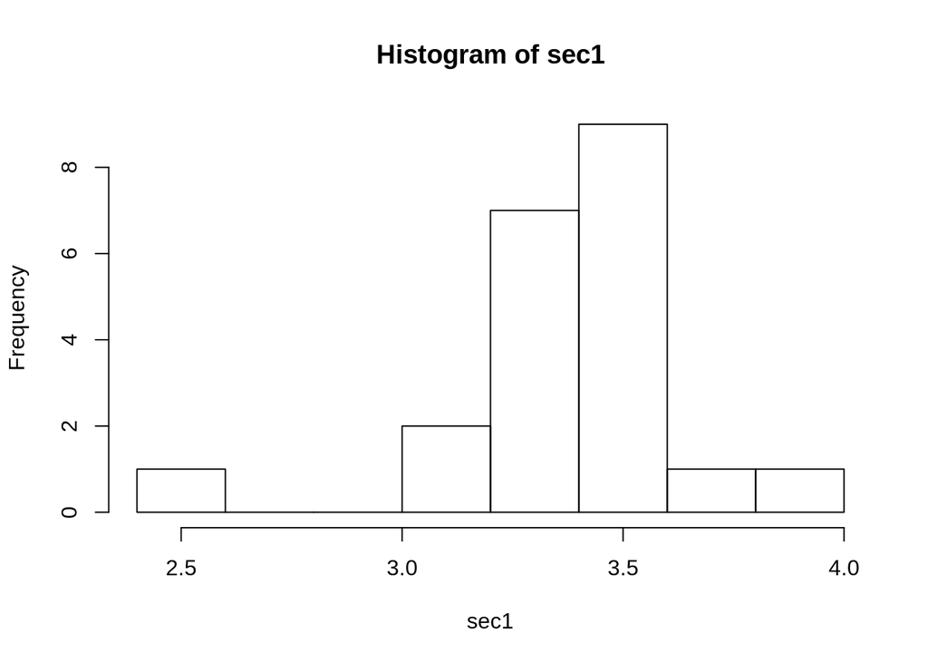

```r
sec1 <- c(3.58,
3.36,
3.56,
3.32,
3.52,
3.54,
2.58,
3.38,
3.44,
3.22,
3.24,
3.2,
3.16,
3.44,
3.24,
4,
3.56,
3.26,
3.44,
3.44,
3.78)

hist(sec1)
```

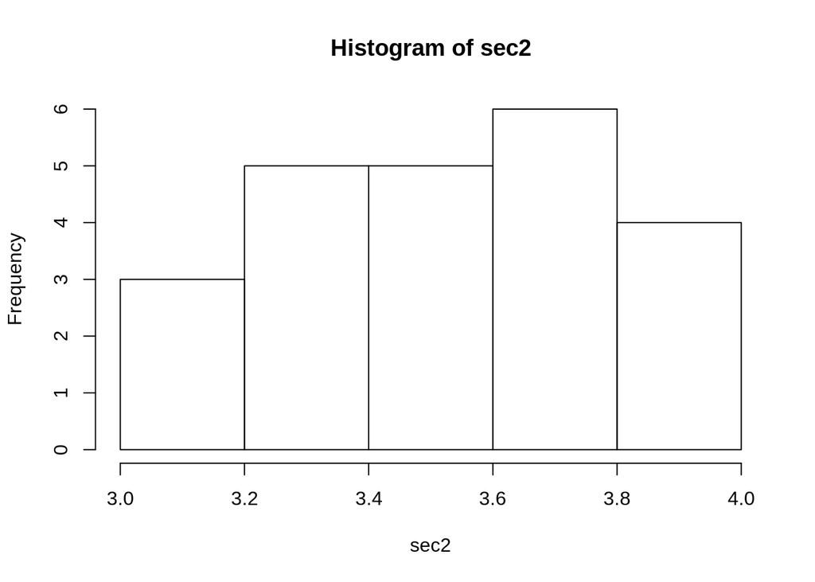

```r
sec2 <- c(3.338983051,
3.033898305,
3.101694915,
3.610169492,
3.474576271,
3.779661017,
3.440677966,
3.152542373,
3.372881356,
3.93220339,
3.559322034,
3.457627119,
3.372881356,
3.372881356,
3.915254237,
3.694915254,
3.627118644,
3.796610169,
3.86440678,
3.694915254,
3.86440678,
3.440677966,
3.203389831)

hist(sec2)
```

```r
summary(sec2)
```

```
##    Min. 1st Qu.  Median    Mean 3rd Qu.    Max.
##   3.034   3.373   3.475   3.526   3.737   3.932
```

# Wednesday

## Sampling Distributions

A sampling distribution is just a probability distribution, for a sample statistic!

Instead of describing individuals, sampling dists talk about entire sample results.

Goal: What’s the probability of a sample result like the one we got?

Two main kinds:

If we’re talking about categorical data, then we want to ask questions about *proportions*! - We hope to say something smart about p (parameter), based on phat (statistic).  
- To do this, we’ll use the samp dist for proportions.

If we’re talking about quant data, then we want to ask questions about *means*! - We hope to say something smart about mu (parameter) based on xbar (stat). - To do this, we’ll need a samp dist for means.

In general, for big n, these things are complex. Let’s look at an easy one:

Sample: roll 2 dice (n=2), find average (xbar).

The original dist (n=1), has a flat distribution. All equally likely. 1s - 6s.

With n=2 (see notes for distribution), xbar has a triangle shape! Totally different! Values towards the center (3.5) are more likely!

## Important Observations about Samp dists

As n increases, valueas towards the center get more and more likely. Extreme values get less likely. Summarized in the Central Limit Theorem:

CLT: as sample size (n) gets larger, sampling distribugions (both for xbar and phat) get closer and closer to the normal dist, NO MATTER WHAT THE ORIGINAL DISTIBRUTION IS!!!! Holy cow!

For large n, the samp dist is essentially a normal dist, no matter what. Woah!

If clt wasn’t true, we’d never know what distribution our samples follow! Forunately, as long as n is large enough, it’s always the same: normal!!

Q: how large is “large enough”?

For means: n >= 30. If your sample size is at least 30, then xbar will follow (very nearly) a normal dist.

For props: to be continued.

Only two things we need to know:

z ( x - mu)/sigma

Need to know: what’s the mean? Mu? What’s the std dev? Sigma? FOR XBAR.

# Wednesday

## Sampling Distributions

A sampling distribution is a probability distribution for a sample statistic.

Instead of describing individuals, samp dists describe whole sample results.

We’ll focus on two main kinds:

If our data is categorical, we’ll ask questions about **proportions**. - We need to be able to find probabilities for sample proportions. - We hope to say something smart about p (parameter) based upon phat (statistic) - We’ll need a sampling dist for phat

If our data is quantitative, we’ll ask questions about **means** - We hope to say something smart about mu (parameter) based upon xbar (stat) - We need a samp dist for xbar

For large samples size (n), these things get complicated. Let’s do an easy one with n=2.

Example) Rolling a dice. Find the average of two dice rolls (n=2).

Interesting observations: shape changes! With n=1 (original distro), we see a flat line. But with n=2, get more of a pyramid. Values in the middle (n=2) are much more likely, values at the extremes are much less likely.

This always happens: when we take averages, the results get closer and closer to the center of the population as n increases.

## Central Limit Theorem

As sample size (n) increases, sampling distributions (both for xbar and phat) get closer and closer to a normal distribution, NO MATTER WHAT POPULATION WE’RE SAMPLING FROM!!!

If the clt weren’t true, then we wouldn’t know what our sampling dists look like! Wouldn’t be able to ask questions about how likely or unlikely they are!

If n is “sufficiently large”, our sampling dist is essentially normal. Doesn’t matter what population, even if it’s super skewed/weird/totally not normal. I.e., we always know the distro! It’s normal!

Q: How large is sufficiently large?

For means: if n>=30, then xbar has a nearly normal dist. For propotions: to be continued.

Ok, we know it’s normal. Still need two things: center and spread of the dist.

z = (x - mean)/stdev

```r
set.seed(1)
sum(sample(0:1, 10, replace=T))
```

```
## [1] 6
```

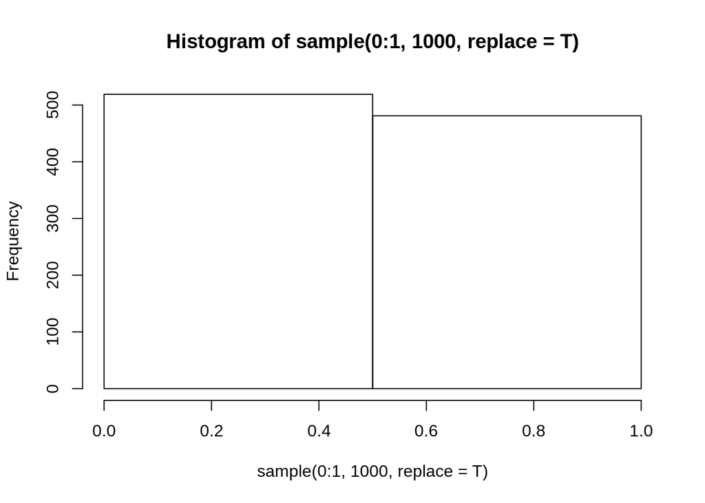

```r
hist(
  sample(0:1, 1000, replace = T),
  breaks=2)
```

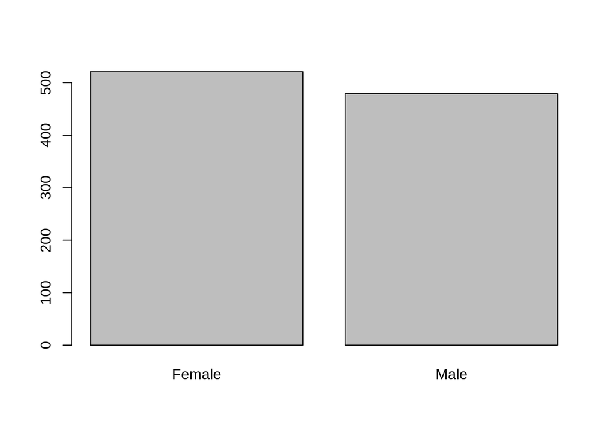

```r
barplot(
  table(sample(0:1, 1000, replace = T)),
  names=c("Female", "Male") )
```

```r
mySpecialSample <- sample(0:1, 1000, replace = T)

mySpecialSample
```

[output not shown]

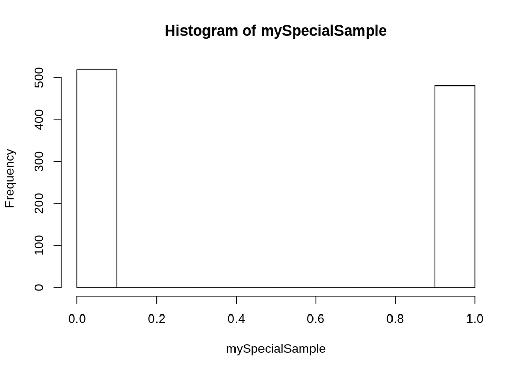

```r
hist(mySpecialSample)
```

```r
mySampleResults <-
  replicate(5000,
            mean(sample(1:6, 1000, replace = T)))
summary(mySampleResults)
```

```
##    Min. 1st Qu.  Median    Mean 3rd Qu.    Max.
##   3.283   3.462   3.499   3.500   3.535   3.685
```

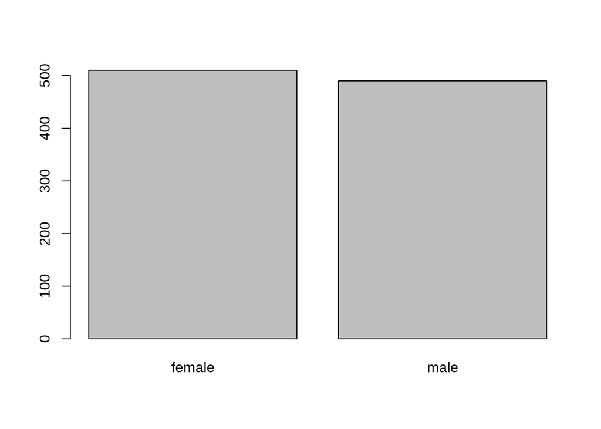

```r
barplot(
  table(
    sample(0:1, 1000, replace=T)
  ),
  names=c("female", "male")
)
```